## Experiment overview

| samplename | group | bulk | single |
| --- | --- | --- | --- |
| C1_TDT | TDT | 1 | 0 |
| C2_TDT | TDT | 1 | 0 |
| C3_TDT | TDT | 1 | 0 |
| C4_TDT | TDT | 1 | 0 |
| B5_TCP | TCP | 1 | 0 |
| B6_TCP | TCP | 1 | 0 |
| B7_TCP | TCP | 1 | 0 |
| B8_TCP | TCP | 1 | 0 |
| scT1 | sc | 0 | 1 |
| scT2 | sc | 0 | 1 |
| scT3 | sc | 0 | 1 |

## Sample clustering and QC

The following heatmap shows a hierarchical clustering of pairwise distances between samples. Darker blue means less distant (i.e. more similar). In general we expect to see replicates clustering together and separation of treatments.

## Clustered heatmap

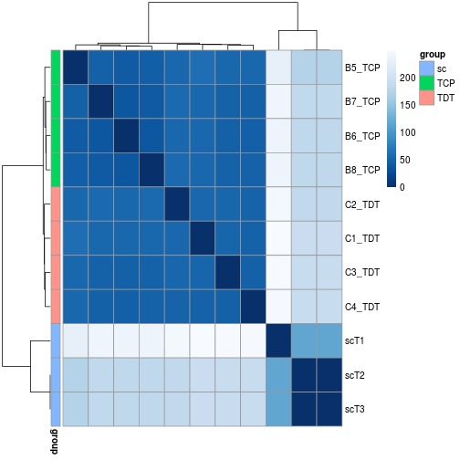

## PCA

Another way of looking at sample clustering is principal components analysis (PCA). The x- and y-axes do not have units, rather, they represent the dimensions along which the samples vary the most. The amount of variance explained by each principal component is indicated in the axes label.

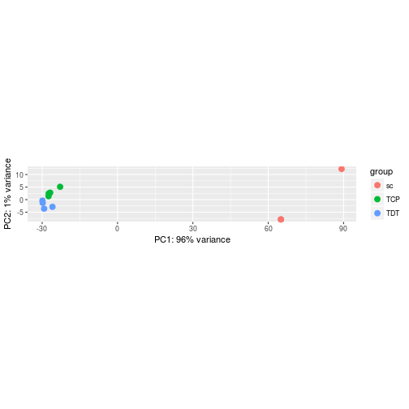

## Most-varying genes

We can also look at the most varying genes to get a sense of the clustering. This heatmap takes the top 50 most-varying genes and plots their deviation from the row mean.

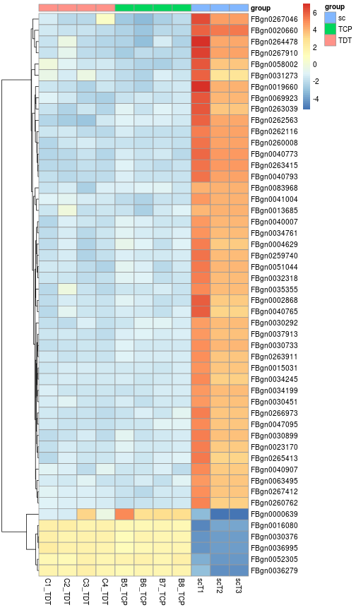

# Differential expression

## TCP vs scRNA-Seq

### Summary of results

| total.annotated.genes | total.nonzero.read.count | alpha | up | down | outliers | low.counts | design |
| --- | --- | --- | --- | --- | --- | --- | --- |
| 14312 | 14179 | 0.01 | 3549 | 3772 | 389 | 1099 | ~group |

### Normalized counts of top 3 upregulated genes

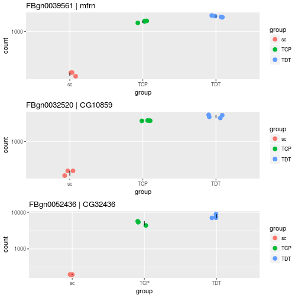

### Normalized counts of top 3 downregulated genes

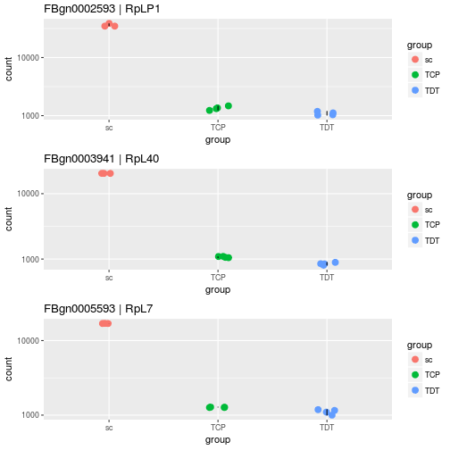

### M-A plot

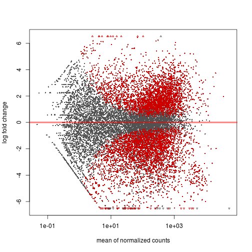

### P-value distribution

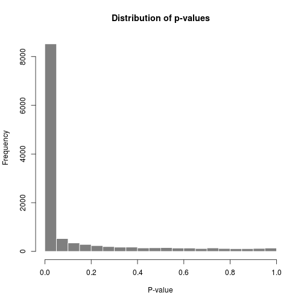

## TDT vs scRNA-Seq

### Summary of results

| total.annotated.genes | total.nonzero.read.count | alpha | up | down | outliers | low.counts | design |
| --- | --- | --- | --- | --- | --- | --- | --- |
| 14312 | 14179 | 0.01 | 3610 | 3681 | 389 | 1649 | ~group |

### Normalized counts of top 3 upregulated genes

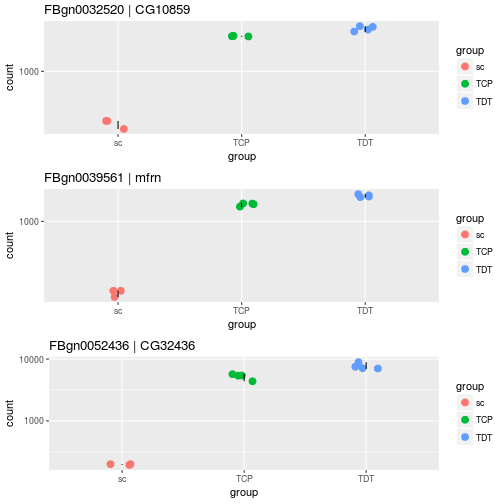

### Normalized counts of top 3 downregulated genes

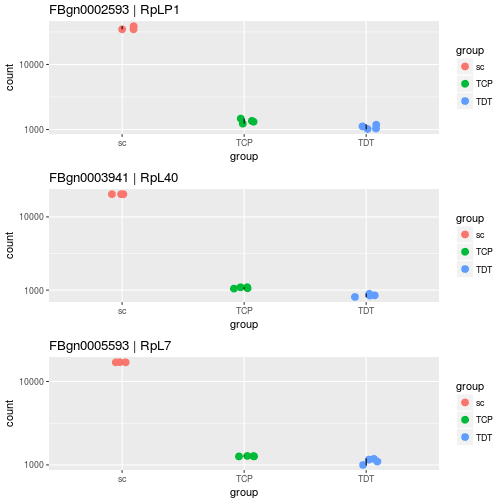

### M-A plot

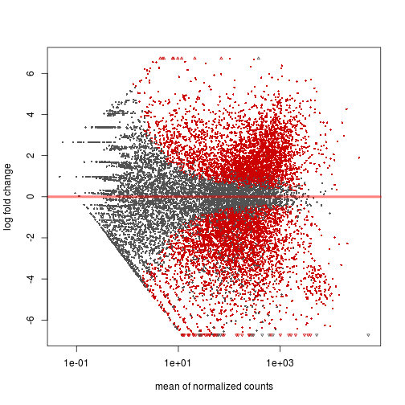

### P-value distribution

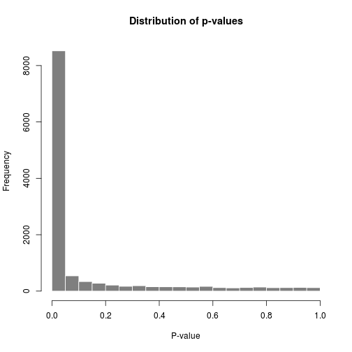

# Exported results

# Gene ontology and KEGG pathway enrichment

Here we perform gene ontology enrichment and KEGG pathway enrichment using the [clusterProfiler](https://bioconductor.org/packages/release/bioc/vignettes/clusterProfiler/inst/doc/clusterProfiler.html) package with some custom plotting functions.

These plots show:

- enriched category (y-axis)
- magnitude of enrichment (x-axis; plotted as -10 log10 (FDR) or “phred” scale)
- fraction of regulated genes falling within a particular category (size)
- experiment (color)
- ontology (sub-panels; BP=biological process, MF=molecular function, CC=cellular component, kegg=KEGG pathway)
- direction of regulation (up- or downregulated; separate figures; labeled at the top)

The full analysis table can be viewed here:

- functional_enrichment.tsv

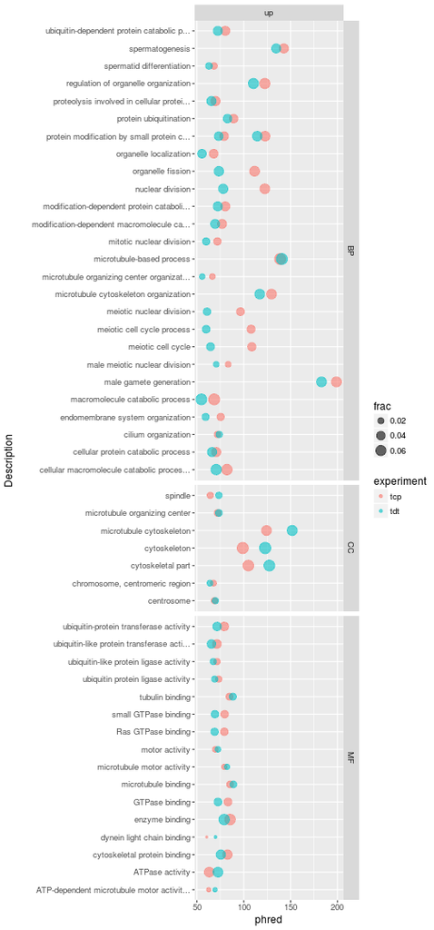

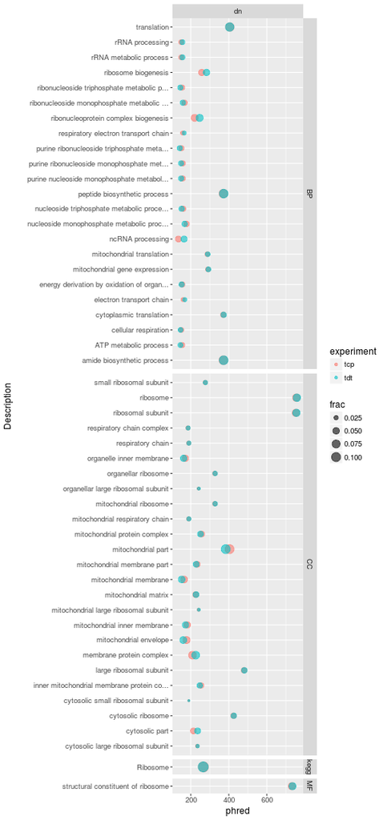

Styled with knitrBootstrap